聖路加国際病院 集中治療科

ST. LUKE'S ICU

# Hotel ICU私たちが目指すICU

**最高の医療と、心温まる Human Care を一つに。**  
患者さん・ご家族・そして働く私たち自身にとって、最高の体験が得られるICUへ。その考え方と、いま取り組んでいることをまとめました。

ICUで働くすべての職種のみなさんへ ｜ 2026年度版

6つの柱を見る ケアラウンド お願いと声の届け方

SCROLL

めざす姿を支える

6つの柱

患者・家族に3本、医療者に3本

ICUの前・中・後をつなぐ

4施策

連続ケア

ケアラウンド

週2回

いまの力点。多職種でベッドサイドへ

MOVIE

## 3分でわかる Hotel ICU

このページの内容を、約3分の動画にまとめました。音声はなく、字幕だけで読めます。

[video not shown]

[figure not shown]

紹介動画（3分24秒・音声なし）は、このページのWeb版で再生できます。

再生時間 3分24秒／音声なし（字幕のみ）。院内のPCでもスマートフォンでも再生できます。

01

INTRODUCTION

## はじめに

「Hotel ICU」という言葉を、聖路加ICUではここ数年、私たちの合言葉として使ってきました。

ICUをホテルのように豪華にしよう、という意味ではありません。一流のホテルは、最新の設備と行き届いた心配りの両方で、訪れた人に「ここに来てよかった」と感じさせます。ICUも同じように、**質の高い医療**と**人として向き合うケア**の両方で、患者さん・ご家族、そして働く私たち自身にとって最高の体験が得られる場所にしたい。それが Hotel ICU です。

このページは、Hotel ICU が何をめざし、いま何に取り組んでいるのかを、医師・看護師・薬剤師・理学療法士・管理栄養士・臨床工学技士、そして関わるすべての事務部門の方々など、ICUで働くすべての方と共有するためにまとめました。

日々皆さんが行なっていることは、全て Hotel ICU に繋がっています。

2025年元日、ICUスタッフのみなさんへのメッセージから

聖路加国際病院 集中治療科 部長 岡本 洋史

02

WHY HOTEL ICU

## なぜ Hotel ICU か

この章の要点

ICU医療は「生存率を上げる」段階を越え、「ICUでどんな時間を過ごしたか」が問われる時代に入りました。

集中治療の進歩で、多くの患者さんが命を取りとめられるようになりました。一方で、ICUを出た後も続く身体・心・認知の不調（PICS：集中治療後症候群）や、ご家族の心の負担が知られるようになっています。治療成績が平準化するほど、患者さんとご家族の記憶に残るのは、ICUで過ごした体験そのものです。

### ICU医療の3つの変化

CHANGE 1

#### 体験価値

治療成績が平準化するほど、患者さん・ご家族の記憶に残るのはICUでの体験そのものになります。

痛み・不安・孤独を、安心と尊厳のある時間に置き換える

CHANGE 2

#### 個別化

ガイドラインは集団に対する標準解です。目の前の一人に当てはめるには、判断が要ります。

その人の価値観と状態に合わせて、ケアを組み立てる

CHANGE 3

#### 高速化

医学の文献は増え続けています。新しい知見を待たずに臨床へ届ける速さが求められます。

AIとも協働して、学びを素早くプロトコールへ

### 世界の潮流ICUを「人間らしく」する動き

Hotel ICU は聖路加だけの思いつきではありません。2010年代後半から、世界のICUで「医療の人間化（humanization）」が大きな流れになっています。

2016

**ICU 人間化計画（スペイン・マドリード州）**ICU Humanisation Plan 2016–2019

面会の開放、コミュニケーション、患者の快適さ、家族の参加、医療者のケア、PICSの予防、人間的な環境、終末期ケアの8つを戦略として掲げました。

2017

**「2050年のICUは、5つ星ホテルのようになる」**Vincent JL, et al. Intensive Care Med 2017

未来のICU像を描いた論文です。Hotel ICU という発想の直接の源流になりました。

2017

**HU-CI プロジェクト**Heras La Calle G, et al. Intensive Care Med 2017

生存率が90%を超えたいま、次の課題は医療の人間化である、と提起しました。

2019

**ICUでの「脱人間化」の構造**Wilson ME, et al. Crit Care 2019

ICUでは患者さんが「一人の人」として扱われにくくなる構造を示し、尊厳を守る実践を提案しました。Helloボードの考え方の背景です。

2020

**人間中心のICUモデル／家族のケア参加**Nin Vaeza N, et al. Crit Care Med 2020 ／ Amass TH, et al. Crit Care Med 2020

1万人を超える声から人間中心のICUモデルが示されました。また、ご家族がケアに加わると、ご家族のPTSD症状が減ることが報告されています。

2026

**人間化を、教えて評価する能力に**Topeli A, et al. Intensive Care Med 2026

患者さん・ご家族中心のケアを個人の善意に任せず、能力の枠組み→教育→評価→実践への組み込み→成果の5段階で育てることが提案されました。土台には心理的安全性・家族の参画・多職種協働を置きます。

2026

**人間中心のパートナーシップ 合意声明**Latour JM, et al. Intensive Care Med 2026（欧州集中治療医学会）

47か国の医療者と元患者さん・ご家族201人の意見を集めた43項目の合意です。柔軟な面会、ご家族のケア参加、多職種での定期的な家族面談、話せない患者さんへの文字盤などの意思伝達具を「行うべき」と推奨しました。AIやVRは合意に至りませんでした。

いま

**聖路加ICUの Hotel ICU**

この国際的な流れを、日本のICUで実践するモデルになることをめざしています。

### Humanization と Human care私たちの言葉づかい

この流れを、聖路加ICUでは2つの言葉で整理しています。

#### Humanizationヒューマナイゼーション

患者さんやご家族を一人の人として尊重できるICUにしていこう、という考え方です。ケアだけでなく、環境・仕組み・医療者の働き方まで含めて整えていきます。

#### Human careヒューマンケア

患者さんとご家族を一人の人として尊重するケアです。Humanization を実現するために、医療者一人ひとりが日々のベッドサイドで行う実践です。

ひとことで

Human care を積み重ねて、ICUを Humanization する。合言葉の「心温まる Human Care」は、この日々の実践のことです。

03

OUR WORDS

## 合言葉とミッション

合言葉

ホテルのようなホスピタリティに満ちたICU  
＝ Hotel ICU

快適さだけでなく、一流ホテルのように最新かつ質の高い医療と心温まる Human Care を融合し、患者・家族・働くスタッフ全員にとって最高の体験が得られる場を目指します。

MISSIONなぜやるのか

科学で「いま」の命を守り、  
思いやりで「その先」の人生につなぐ。

重症の患者さんとご家族、そして共に働く仲間のために。チームの言葉 “Our science is for the critical present. Our cheer and compassion are for the brighter future.” を日本語にしました。

VISION2030年になっていたい姿

2030年、ICUを出た患者さんとご家族が  
「怖くなかった、ここでよかった」と言い、  
スタッフが「働き続けたい」と言えるICUに。

そしてその形を、日本のICUのモデルとして届けます。

治すのは科学、癒すのはアート。私たちは、その両方を手放しません。

ウィリアム・オスラー「医学は科学に基礎づけられたアートである」から

日々の行動が上へ積み上がる

ミッションなぜやるのか

ビジョンなりたい姿

戦略 ＝ 6つの柱力を入れる領域

戦術 ＝ 日々の行動今日、一人ひとりがやること

**図2**ミッションからベッドサイドの行動まで。いちばん大きな土台は、みなさん一人ひとりの日々の行動です。

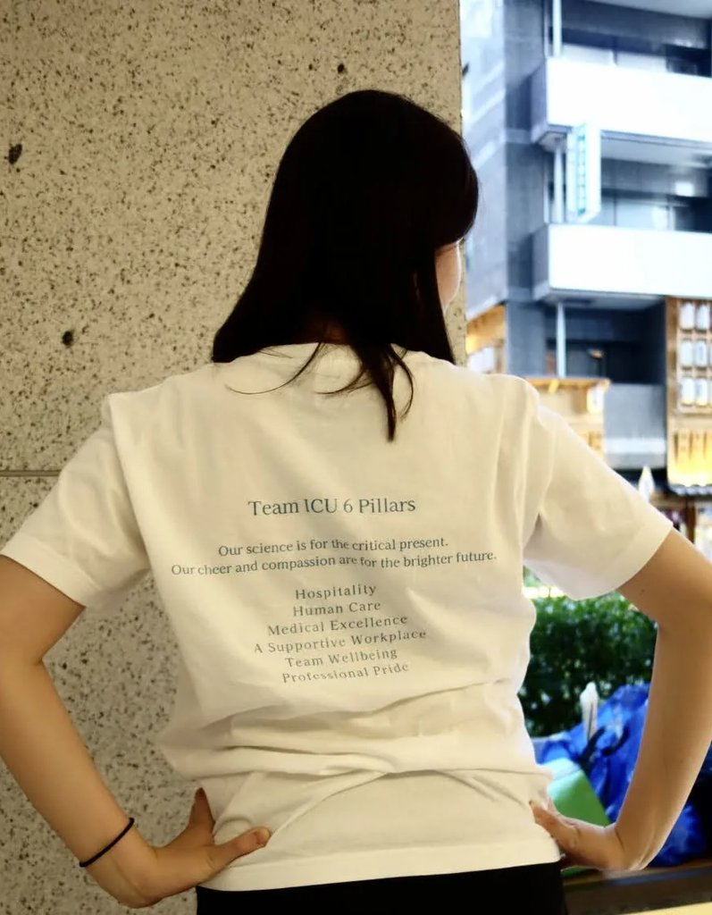

2025年の聖路加ICU運動会でつくったチームTシャツ。背中には、ミッションのもとになった言葉と、6つの柱の英語名が入っています。

04

SIX PILLARS

## 6つの柱

この章の要点

患者さん・ご家族のための3本と、それを支える医療者のための3本。医療者が満たされて初めて、患者さんに「ホテル」を届けられます。

誰かの無理で回るICUを、昔話にする。

亀田総合病院 白石淳先生「医師が無茶をする時代を昔話に」から

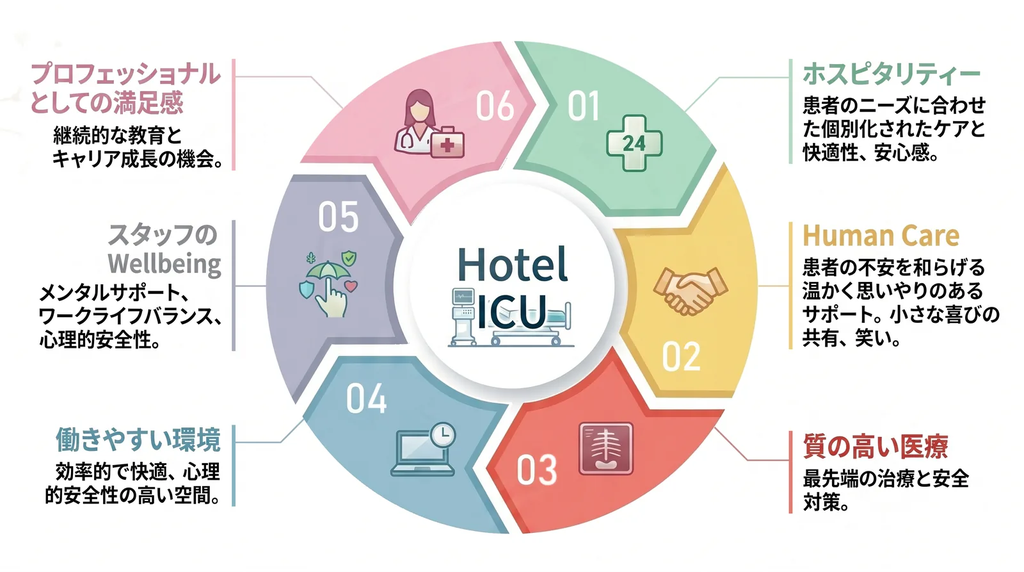

**図3**Hotel ICU の6つの柱。右上の01から時計回りに読みます。右の3本（01〜03）が患者さん・ご家族のため、左の3本（04〜06）が医療者のためです。

01

#### ホスピタリティー

Hospitality

患者・家族のために

一人ひとりに合わせた、安心で快適な場をつくる

やること

- 価値観・希望に合わせた個別化ケア
- 音・光・温度の管理（アラーム対応・遮音カーテン）
- 夜は処置やケアをまとめて、90分以上途切れずに眠れる時間をつくる（目安）
- 柔軟な家族面会、わかりやすい説明と意思決定支援

なぜ

治療成績が平準化するほど、記憶に残るのはICUでの体験そのものだからです。

つなぐシート 運用3年

02

#### Human Care

人として向き合う

患者・家族のために

不安と恐怖に寄り添い、ふだんの人と同じように接する

やること

- 毎日の挨拶・目を見て話す・処置前の声掛け
- 心理的サポート
- 小さな喜びの共有（面会・音楽・食事の体験）
- ご家族が初めて面会する前に、これから目にする姿（チューブ、手の抑制、むくみなど）をひとこと伝えておきます
- 節目の家族面談の合間も、職種を問わず毎日、数分でよいのでご家族に声を掛け、困りごとを伺います

なぜ

ICUでは患者さんが「一人の人」でなくなりやすいからです。ご家族がケアに加わると、ご家族のPTSD症状が減ることもわかっています。

HelloボードケアラウンドICUダイアリー

03

#### 質の高い医療

Medical Excellence

患者・家族のために

ホテルのような心地よさは、最高の医療の上に成り立つ

やること

- 職種ごとの知識の更新と教育、プロトコール化
- チームでの質改善
- インシデントの共有、手指衛生・感染予防による医療安全

なぜ

「ホテルのよう」は甘やかしではありません。個別化と高速化に応える医療そのものです。

聖路加ICUマニュアル刊行質指標38項目

04

#### 働きやすい環境

A Supportive Workplace

医療者のために

設備とデジタルで、余計な負担をなくす

やること

- 必要な設備・物品の整備
- ICU・休憩室・仮眠室を快適に
- デジタル活用とタスクシフト・シェア

なぜ

働く環境が整ってこそ、患者さんに良いケアを届けられるからです。

ナースコール連動スマートフォンラベルプリンター

05

#### スタッフの Wellbeing

Team Wellbeing

医療者のために

安心して話せて、休めるチームにする

やること

- 自由に意見を言える心理的安全性
- 疲れたスタッフへのメンタルサポート
- 余力のある人員配置と、休暇の取りやすさ

なぜ

自分たちが満たされていなければ、患者さんを幸せにはできないからです。挨拶・感謝・掲示を中心にした4週間の取り組みで、ICUスタッフのバーンアウトの割合が63.3%から52.2%に下がったという、60か国370のICUでの無作為化試験もあります。

運動会・親睦会「またやりたい」の声

06

#### プロフェッショナルとしての満足感

Professional Pride

医療者のために

成功を分かち合い、成長し続けられる場にする

やること

- 成功と感謝を共有する文化
- 継続教育（院外講師・シミュレーション・学会参加）
- 学術支援・資格取得などのキャリア支援

なぜ

成長の実感とフィードバックがあってこそ、プロとして長く働き続けられるからです。

年間コアレクチャー表多職種で書いたマニュアル

Hospitality

Human Care

Medical Excellence

A Supportive Workplace

Team Wellbeing

Professional Pride

Team ICU 6 Pillars（チームTシャツの英語表記）

05

CONTINUUM OF CARE

## 連続ケアとケアラウンド

この章の要点

ICUに入る前から、ICUにいる間、ICUを出たあとまで。4つの施策で「その人」を切れ目なくつなぎます。いまの力点は、ICUにいる間の予防＝ケアラウンドです。

ICUの仕事は、命を救って終わりではありません。回復し、満たし直すところまで。

Todd Dorman（米国集中治療医学会）「予測と予防、治療、そして回復と補充」から

ICU前

ICU中

ICU後

ICU前

#### あなたの想いをつなぐシート

その人が何者で、何を大切にしているかを事前に知る

運用3年

ICU中

#### Helloボード

ベッドサイドでその人らしさを見えるようにする

導入済み

いまの力点

ICU中

#### ケアラウンド

多職種で週2回ベッドサイドへ。困りごとを聞き、その場で解決する

2026年4月から

ICU後

#### ICUダイアリーとPICSの説明

ICUで書いた日記を退室後に手渡し、ICUのあとに起こりうる不調を伝える

続けています

**図4**連続ケアの4施策。ICUに入る前に「その人」を知り、ICUにいる間はその人らしさを見える形にして困りごとをその場で解決し、ICUを出たあとも日記と説明でつながります。

### 退室後訪問で聞いてきた声2024年度

ICUを出た患者さんを病棟に訪ね、ICUでの体験や今の困りごとを伺う「ICU退室後訪問」を続けてきました。2024年度は、ICUに4日以上いた方を多職種で訪ねました。

多職種で訪問

22人

ICUに4日以上いた33人のうち

ICUでつらかったことがあった

13人

訪問した22人のうち

口渇を覚えていた

約3割

訪問した22人のうち7人

活気が入室時より改善

17人

訪問した22人のうち

#### ✓聞こえてきた声

- つらかった記憶は、挿管チューブや息苦しさなど、呼吸に関するものが多い
- 口渇は、約3割の方が覚えていた
- 病棟に移ったあとも、不眠・不安・悪夢を抱える方がいた

#### ×見えた限界

- 苦痛を知るのは、それが「すでに過去のこと」になってから
- ICUでのつらさに、その場で介入することはできない
- 苦痛を取り除く機会を逃していた

苦痛を過去のことにしないために、力点をICUにいる間の予防へその答えがケアラウンドです。ICUを出たあとのつながりはICUダイアリーで続けています

**図5**2024年度のICU退室後訪問から（2024年12月〜2025年2月の集計）。聞いた声をもとに、困りごとを聞くタイミングの力点を、ICUを出たあとからICUにいる間へ移しました。

### ケアラウンド2026年4月から

退室後訪問で聞いた声を、次の患者さんのためだけでなく、いまICUにいる患者さんのために生かす。そのために2026年4月に始めたのが「ケアラウンド」です。ICUを出たあとの訪問は、看護師がICUダイアリーを手渡す訪問として続いています（6章）。

#### 何のために

患者さんのもとへ行き、気にかけ、ケアする。多職種で、週2回、確実にやる。それが私たちのICUの文化になる。

ケアラウンドの説明資料から

ICUにいる患者さんの身体・心・環境の困りごとを見つけ、その場で介入して取り除くことが目的です。介入の結果は翌日に確かめます。

#### 誰に

ICUに入室中で、意思の疎通ができる方。せん妄があっても、挿管中でも対象です。在室2日以上の見込みの方に伺います。

#### 誰が

医師・看護師・薬剤師・管理栄養士・理学療法士。2人以上の多職種で伺います。

#### いつ

週2回（月・金）。午前にスクリーニング、午後にベッドサイドへ。1人約10分です。

#### 何を

専用のチェックリスト（30項目）で身体・心・環境を見て、課題を見つけたらその場で介入し、前後を記録します。

1. **スクリーニング**月・金の午前

   理学療法士が、対象に当てはまる患者さんをリストにして、チームに共有します。
2. **ラウンド**月・金の午後

   2人以上の多職種でベッドサイドへ。チェックリストに沿って、約10分お話を伺います。
3. **その場で介入＋記録**ラウンド中

   課題が見つかったら、その場で介入し、シートに記録します。
4. **受け持ち看護師へ申し送り**ラウンドのあと

   チェックシートを血ガス板の最下面に置き、看護師の間で引き継ぎます。
5. **翌日に評価**翌日の日勤

   受け持ち看護師が介入の結果を評価し、改善・変化なし・悪化などで記録します。

**図6**1回のケアラウンドの流れ。緑の4・5は、受け持ち看護師のみなさんの大切な役割です。

**身体的快適性**15項目

挿管チューブの苦痛、ベッド・クッション、口渇・痛み、排泄・カテーテル、栄養・飲水、睡眠

**環境**4項目

照明、騒音・アラーム音、室温・寒暖、プライバシー

**精神・感情面**5項目

不安・恐怖、孤独感、悪夢、幻覚・せん妄

**尊厳・コミュニケーション**6項目

意思を伝える手段、ナースコール、病状・見通しの理解、希望する活動、面会・家族との連絡

**図7**ケアラウンドのチェックリスト（全30項目）。4つの軸で、患者さんの心地よさを包括的に見ます。

ノルウェーの6つのICUで、口渇・痛み・不安・疲労・息苦しさを多く訴え続けた患者さん（16.0%）は、3か月後に身体・認知・心の5つの領域すべてで困りごとを抱えやすいことがわかっています（オッズ3.3〜4.7倍）。ICUにいる間の訴えを聞くことは、その先の回復を見守る手がかりにもなります。

#### 力点の移り方

これまでの力点：ICU退室後訪問

いまの力点：ケアラウンド

いつ聞くか

ICUを出たあと

ICUにいる間（週2回）

見つけた困りごと

過去のこととして把握する

その場で介入し、翌日に結果を確かめる

引き継いだもの

患者さんから直接聞くこと。退室後訪問で多く聞かれた口渇・不眠・幻覚などは、チェックリストの項目に入っています。

ICUを出たあと

ICUダイアリーの手渡しとPICSの説明を続けています。手渡しのときに、ICUでの記憶や体験を伺います（6章）。

2026年4月のパイロット運用では、最も多かった訴えは口渇でした。医学的な介入から生活の質に関わる調整まで、1回のラウンドでその場で対応できています。

06

AFTER THE ICU

## ICUを出たあとも

この章の要点

ICUダイアリー（ICU日記）の手渡しとPICSの説明で、ICUを出たあとの患者さん・ご家族とのつながりを続けています。

ケアラウンドでICUにいる間のつらさを減らしても、ICUを出たあとの身体・心・認知の不調（PICS）がなくなるわけではありません。ICUを出たあとのケアは、いまも続けています。

### ICUダイアリー（ICU日記）病院全体の取り組み

PICSの予防を目的とした日記です。ICUでの実際の体験と、患者さんご自身の記憶とのずれを埋めます。その日に何があったか、どんな治療や出来事があったか、患者さんがどんな様子だったかを書き残すことで、ICUにいた間の記憶を組み立て直す手助けになり、妄想的な記憶を防ぐことができます。PICSはご家族に現れることもあり、ダイアリーはご家族の支えにもなります。

集中治療領域のPICSチームがつくった院内共通の手順です。ICUの看護師が書き始め、一般病棟の看護師とも連携して、患者さんやご家族のもとへ届けます。

#### 誰にICU

人工呼吸器（NIVを含む）を24時間以上使う見込みの方。挿管していない意識障害の方で、もともと身の回りのことが自立し、回復が見込める方。

#### 誰がICUの看護師

その日にあったこと、治療や出来事、患者さんの様子を書き残します。

1. **書き始める**ICUにいる間

   対象の患者さんのダイアリーを始めます。
2. **患者さんに手渡す**一般病棟に移ったあと

   ICUの看護師が病棟へ伺い、患者さんに手渡します。そのときに、ICUでの記憶や体験を簡単に伺います。
3. **ご家族に渡す**患者さんに渡せないとき

   一般病棟の看護師がご家族にお渡しします。意識が戻らない場合（JCS 100〜300）は、一般病棟の看護師へお渡しを依頼します。
4. **記録する**渡したあと

   ダイアリーのコメントオーダーに、渡した日付を追記します。

**図8**ICUダイアリーの流れ。緑の3・4は、一般病棟の看護師のみなさんにお願いしている役割です。

### PICSの説明資料

#### 患者さん・ご家族へ

パンフレット「集中治療室に入院された患者さんとご家族の方へ」（2025年3月改訂）

- 患者さん：体が思うように動かない・だるい、やる気が出ない・不安・気分が沈む、悪夢・眠れない、物忘れ
- ご家族：やる気が出ない・不安・気分が沈む、悪夢・眠れない
- 相談先：入院中は病棟の看護師、退院・転院後は病院の代表電話（平日 9〜16時）

#### ひと目でわかるPICSとは

PICSを1枚で説明する資料（集中治療領域のPICSチーム）

- 症状：不安・抑うつ・PTSD、記憶障害・注意散漫・実行機能障害。不眠や悪夢として現れることも
- 要因：病気と重症度、治療やケア、環境（アラーム音・光・閉ざされた空間）、不眠や家族の不安
- ICUダイアリーの役割と、ご家族への活用

日本の21のICUで敗血症から回復した患者さんのご家族を追った研究では、不安・抑うつ・PTSDの症状があるご家族は退院後12か月でも42.0%で、ほとんど減りませんでした。患者さんに心の症状があると、ご家族も症状を抱えやすくなります（約3.7倍）。ダイアリーを手渡すときに患者さんの気持ちのつらさに気づいたら、ご家族にも声を掛け、パンフレットの相談先をお伝えください。

要因に挙がる「アラーム音・光」は、ケアラウンドのチェックリストでも見ています。PICSが疑われる相談が病棟や患者さん・ご家族からあれば、院内のPICSチームで対応を検討します。

07

TO OUR TEAM

## お願いと声の届け方

この章の要点

Hotel ICU は特別なプロジェクトではなく、毎日のベッドサイドの積み重ねです。今日からできることを8つにまとめました。

何も言われないのは、うまくいっている証拠とは限りません。だから、私たちから聞きに行きます。

### 患者さん・ご家族のために

**毎日の挨拶、目を見て話す、処置の前に声を掛ける**

ふだん健康な人にするのと同じ接し方を、どの職種も、毎回。ベッド番号や病名ではなく名前で呼び、入室時に、本人が望む呼び方を確かめて記録に残します。

**ベッドサイドと処置中は「患者さんの場」**

患者さんが同席している会議室だと思って、会話の内容と声の大きさを選んでください。

**話しかける前に、つなぐシートと Helloボードを**

その人が何を大切にしているかを知ってから話すと、会話が変わります。気づいたことは書き足してください。挿管中などで話せない方には、うなずき・文字盤・筆談など、その人が伝えやすい方法を確かめ、記録と申し送りで引き継いでください。文字盤と筆記用具は、探さなくても手の届く場所に置きます。

### 看護師のみなさんへICUダイアリーとケアラウンドのあとで

**ICUダイアリーに、その日のことを書き残す**

その日にあったこと、治療や出来事、患者さんの様子を。ICUにいた間の記憶を組み立て直す手助けになり、ご家族の支えにもなります。

**チェックシートを確認し、申し送りで引き継ぐ**

ラウンドで見つかった課題と、その場で行った介入が書かれています。看護師の間で引き継いでください。

**翌日の日勤で、結果を記入する**

介入の結果（改善・変化なし・悪化など）をシートに書いてください。そこからの継続ケアが、いちばん大切です。

### チームのために

**うまくいったこと、ありがとうを言葉にする**

成功と感謝を共有する文化は、6つ目の柱そのものです。

**気づいたことは、その場で声に**

小さな違和感が、いちばん早い改善の種になります。

### 声の届け方

いつでも**身近なリーダーへ**

気づいたこと・困っていることは、各職種のリーダーに、その場で伝えてください。

ケアラウンド**ケアラウンドのコアメンバーへ**

ケアラウンドについての疑問やご意見は、コアメンバーに気軽に声を掛けてください。

08

REFERENCES

## 参考文献

1. Vincent JL, et al. *Intensive care medicine in 2050: the future of ICU treatments.* Intensive Care Med. 2017.
2. Heras La Calle G, et al. *A plan for improving the humanisation of intensive care units.* Intensive Care Med. 2017.
3. Consejería de Sanidad, Comunidad de Madrid. *Plan de Humanización de las Unidades de Cuidados Intensivos 2016–2019.*（ICU 人間化計画・8つの戦略ライン）
4. Nin Vaeza N, et al. *Humanizing Intensive Care: Toward a Human-Centered Care ICU Model.* Crit Care Med. 2020.
5. Wilson ME, et al. *Humanizing the intensive care unit.* Crit Care. 2019.
6. Amass TH, et al. *Family Care Rituals in the ICU to Reduce Symptoms of Post-Traumatic Stress Disorder in Family Members.* Crit Care Med. 2020.
7. Topeli A, et al. *Training for humanization in intensive care: a competency-based educational continuum for patient- and family-centred practice.* Intensive Care Med. 2026.
8. Saltnes-Lillegård C, et al. *Self-reported symptoms in ICU patients and their impact on long-term outcomes—a prospective multicenter study.* Intensive Care Med. 2025.
9. ILOSS Study Group. *Long-Lasting Mental Disorders in Caregivers of ICU Sepsis Survivors and Their Association With Patients' Post-Intensive Care Syndrome: A Prospective Multicenter Cohort Study.* Crit Care Med. 2026.
10. Latour JM, et al. *European Society of Intensive Care Medicine consensus statement on human-centred partnership in the intensive care unit.* Intensive Care Med. 2026.